# Fitting a power law to avalanches size distribution

Hugo Pineda

December 15, 2015

#### Entropy files

```
## [1] "./data/entropy/transposed/output-csv-entropy_P-True-100_H-True-1_N-1_I-False_S-15000_M-256.csv_transposed.csv"
## [1] "./data/entropy/transposed/output-csv-entropy_P-True-10_H-True-1_N-1_I-False_S-15000_M-256.csv_transposed.csv"
## [1] "./data/entropy/transposed/output-csv-entropy_P-True-15_H-True-1_N-1_I-False_S-15000_M-256.csv_transposed.csv"
## [1] "./data/entropy/transposed/output-csv-entropy_P-True-1_H-True-1_N-1_I-False_S-15000_M-256.csv_transposed.csv"
## [1] "./data/entropy/transposed/output-csv-entropy_P-True-25_H-True-1_N-1_I-False_S-15000_M-256.csv_transposed.csv"
## [1] "./data/entropy/transposed/output-csv-entropy_P-True-2_H-True-1_N-1_I-False_S-15000_M-256.csv_transposed.csv"
## [1] "./data/entropy/transposed/output-csv-entropy_P-True-50_H-True-1_N-1_I-False_S-15000_M-256.csv_transposed.csv"
## [1] "./data/entropy/transposed/output-csv-entropy_P-True-5_H-True-1_N-1_I-False_S-15000_M-256.csv_transposed.csv"
```

#### Avalanche files

```
## [1] "./data/avalanches/output-csv-avalanche_P-True-100_H-True-1_N-1_I-False_S-15000_M-256.csv"
## [1] "./data/avalanches/output-csv-avalanche_P-True-10_H-True-1_N-1_I-False_S-15000_M-256.csv"
## [1] "./data/avalanches/output-csv-avalanche_P-True-15_H-True-1_N-1_I-False_S-15000_M-256.csv"
## [1] "./data/avalanches/output-csv-avalanche_P-True-1_H-True-1_N-1_I-False_S-15000_M-256.csv"
## [1] "./data/avalanches/output-csv-avalanche_P-True-25_H-True-1_N-1_I-False_S-15000_M-256.csv"
## [1] "./data/avalanches/output-csv-avalanche_P-True-2_H-True-1_N-1_I-False_S-15000_M-256.csv"
## [1] "./data/avalanches/output-csv-avalanche_P-True-50_H-True-1_N-1_I-False_S-15000_M-256.csv"
## [1] "./data/avalanches/output-csv-avalanche_P-True-5_H-True-1_N-1_I-False_S-15000_M-256.csv"
```

#### Summary of used parameters

| perturb | perturb_n | hierarchy | hierarchy_n | neighbours_level | update | steps | M |
| --- | --- | --- | --- | --- | --- | --- | --- |
| TRUE | 1 | TRUE | 1 | 1 | FALSE | 15000 | 256 |
| TRUE | 2 | TRUE | 1 | 1 | FALSE | 15000 | 256 |
| TRUE | 5 | TRUE | 1 | 1 | FALSE | 15000 | 256 |
| TRUE | 10 | TRUE | 1 | 1 | FALSE | 15000 | 256 |
| TRUE | 15 | TRUE | 1 | 1 | FALSE | 15000 | 256 |
| TRUE | 25 | TRUE | 1 | 1 | FALSE | 15000 | 256 |
| TRUE | 50 | TRUE | 1 | 1 | FALSE | 15000 | 256 |
| TRUE | 100 | TRUE | 1 | 1 | FALSE | 15000 | 256 |

## Entropy over time

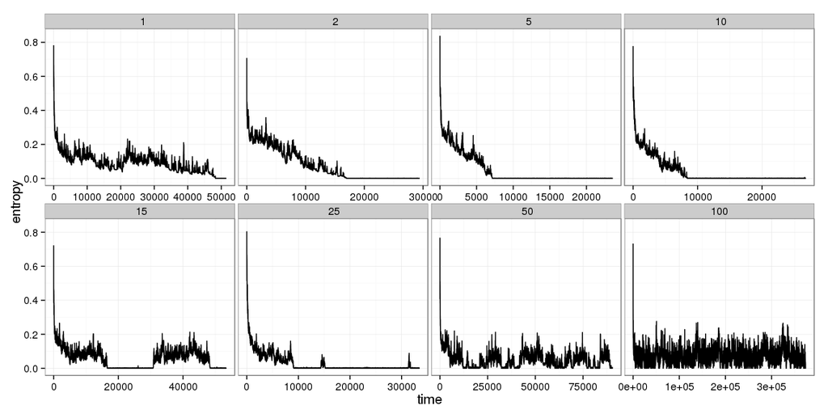

# Use all the avalanche values

## Avalanche size (affected cells)

### Avalanche size (affected cells) over time

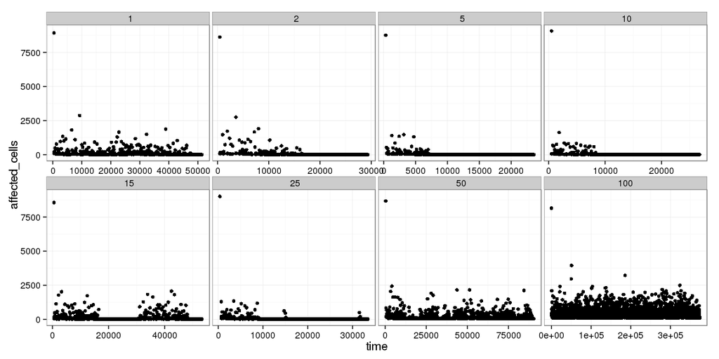

### Histogram approach

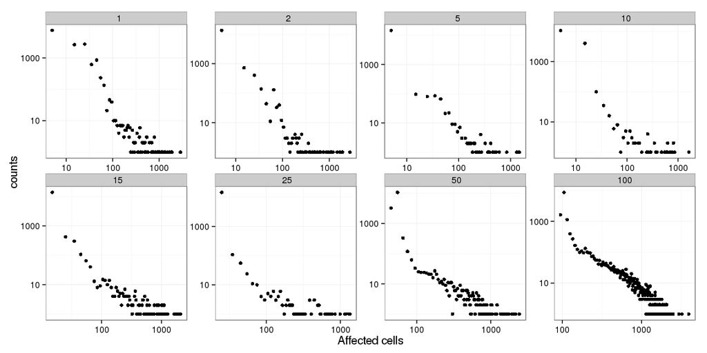

### Cumulative distribution function approach

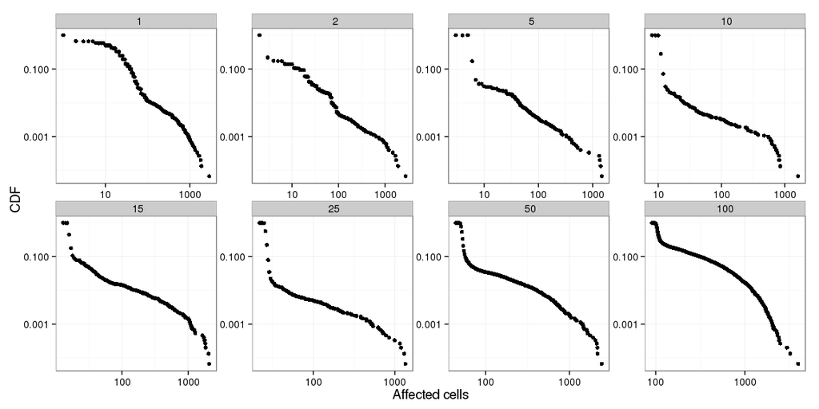

### Results of the fit

Here I use the power.law.fit function from igraph package because it calculates statitics without bootstraping, so much faster. The approach is to use this method to explore the different perturbation sizes and then use bootstrap over one of them. From the function help this is what the statistics means:

- alpha: the exponent of the fitted power-law distribution.
- xmin: the minimum value from which the power-law distribution was fitted. In other words, only the values larger than xmin were used from the input vector.
- KS: the test statistic of a Kolmogorov-Smirnov test that compares the fitted distribution with the input vector. Smaller scores denote better fit.
- KS.pvalue: the p-value of the Kolmogorov-Smirnov test. Small p-values (less than 0.05) indicate that the test rejected the hypothesis that the original data could have been drawn from the fitted power-law distribution.

| perturb_n | xmin | alpha | KS | KS_p_value |
| --- | --- | --- | --- | --- |
| 1 | 86 | 2.006660 | 0.0782724 | 0.1452342 |
| 2 | 154 | 2.059174 | 0.0742025 | 0.9323139 |
| 5 | 46 | 2.153593 | 0.0352462 | 0.9973151 |
| 10 | 15 | 2.062056 | 0.0777046 | 0.0473387 |
| 15 | 44 | 1.888979 | 0.0641402 | 0.0685399 |
| 25 | 47 | 1.982772 | 0.0765161 | 0.3681063 |
| 50 | 572 | 3.352674 | 0.0507766 | 0.9686589 |
| 100 | 1656 | 6.902673 | 0.0365503 | 0.9999999 |

## Avalanche length

### Avalanche length over time

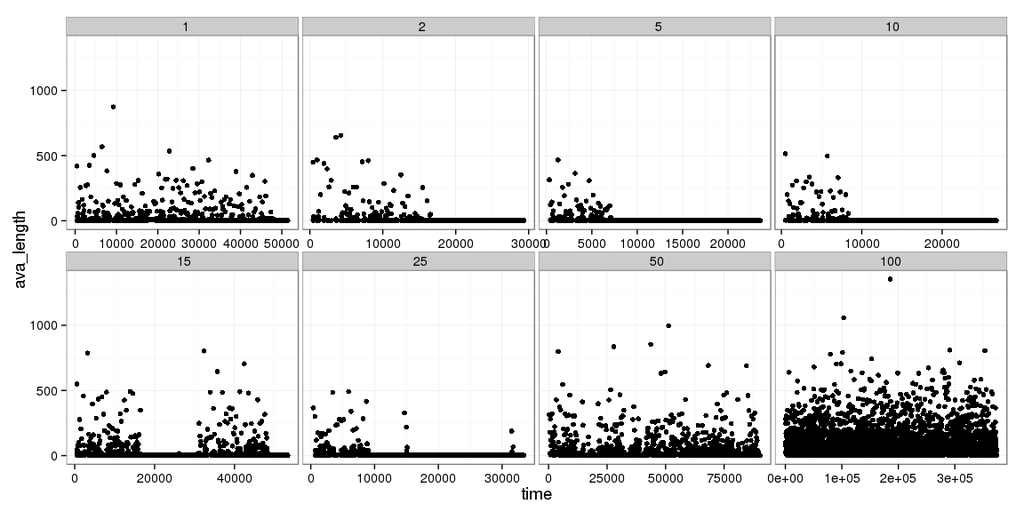

### Histogram approach

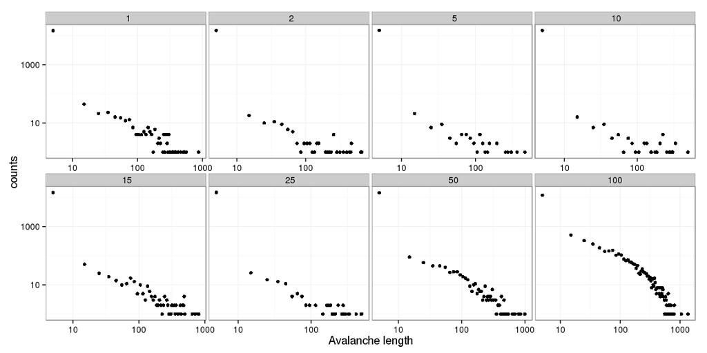

### Cumulative distribution function approach

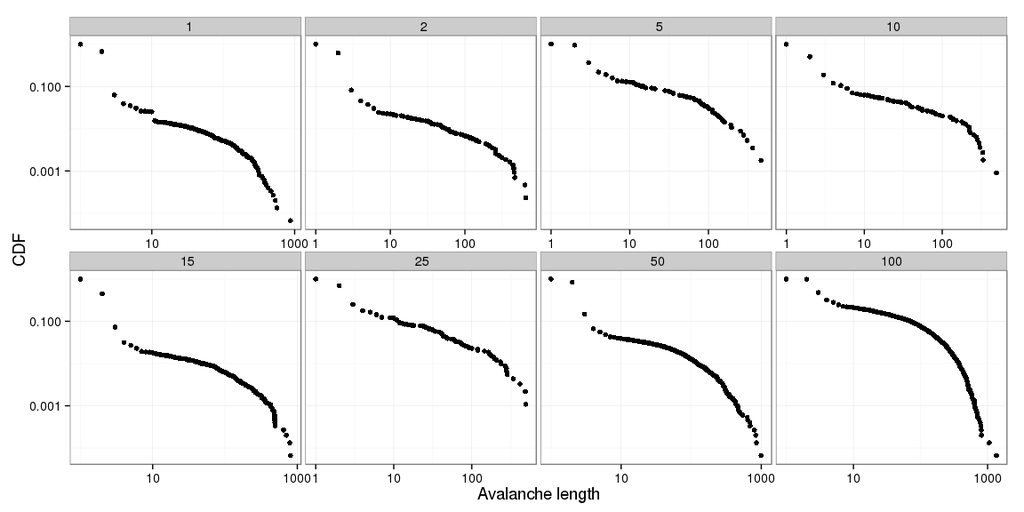

### Results of the fit

| perturb_n | xmin | alpha | KS | KS_p_value |
| --- | --- | --- | --- | --- |
| 1 | 252 | 4.288188 | 0.0555859 | 0.9999912 |
| 2 | 32 | 1.866177 | 0.0908447 | 0.6568163 |
| 5 | 76 | 2.692602 | 0.0905464 | 0.9833569 |
| 10 | 1 | 1.926659 | 0.0865699 | 0.0000001 |
| 15 | 104 | 2.348432 | 0.1004274 | 0.3177441 |
| 25 | 25 | 1.940498 | 0.0822152 | 0.7475366 |
| 50 | 259 | 3.613809 | 0.0631823 | 0.9767783 |
| 100 | 467 | 6.118841 | 0.0582973 | 0.9607449 |

# Now repeat the same but filtering the avalanches values where entropy did not change anymore

- From perturb_n 2 remove all the points time > 18000
- From perturb_n 5 remove all the points time > 7000
- From perturb_n 10 remove all the points time > 9000
- From perturb_n 25 remove all the points time > 10000

## Entropy over time

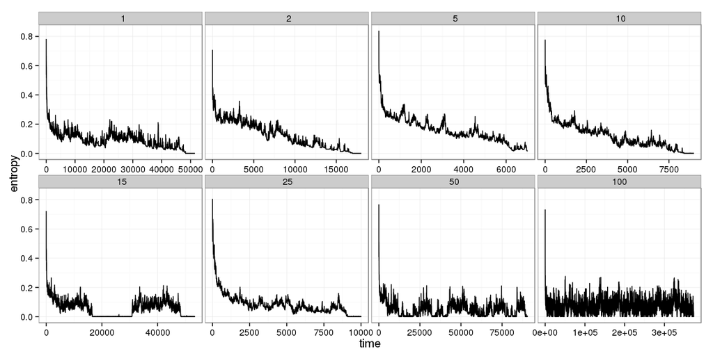

## Avalanche size (affected cells)

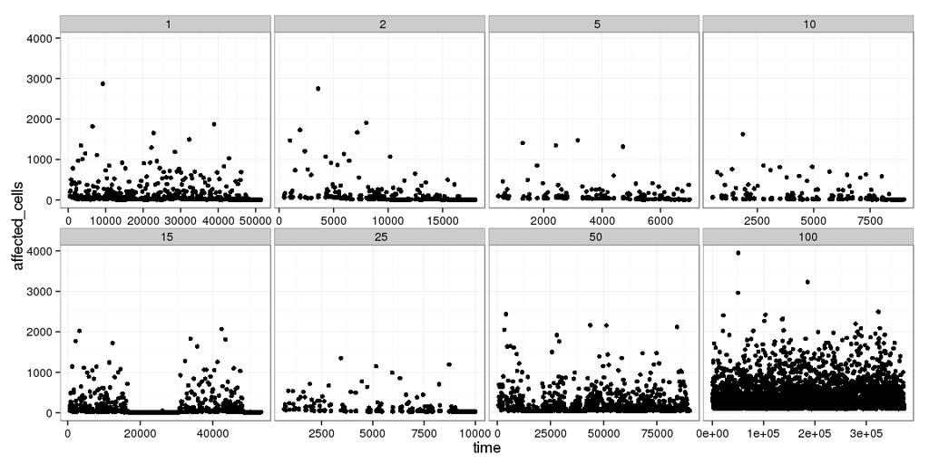

### Histogram approach

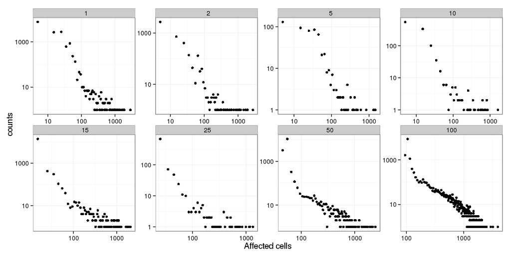

### Cumulative distribution function approach

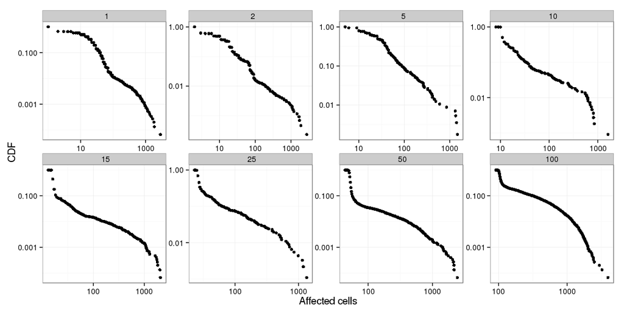

### Results of the fit

| perturb_n | xmin | alpha | KS | KS_p_value |
| --- | --- | --- | --- | --- |
| 1 | 86 | 1.998562 | 0.0784198 | 0.1473843 |
| 2 | 154 | 2.059174 | 0.0742025 | 0.9323139 |
| 5 | 46 | 2.156733 | 0.0389338 | 0.9918424 |
| 10 | 12 | 2.103213 | 0.0604062 | 0.0996217 |
| 15 | 44 | 1.886389 | 0.0646074 | 0.0663396 |
| 25 | 35 | 2.032354 | 0.0691499 | 0.3360579 |
| 50 | 572 | 3.349521 | 0.0506676 | 0.9707601 |
| 100 | 1656 | 6.951091 | 0.0403437 | 0.9999977 |

## Avalanche length

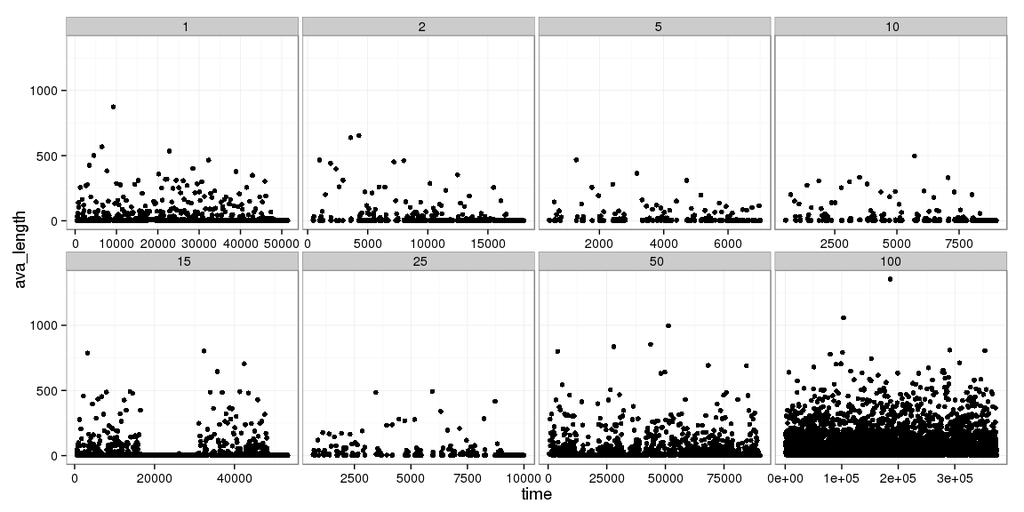

### Histogram approach

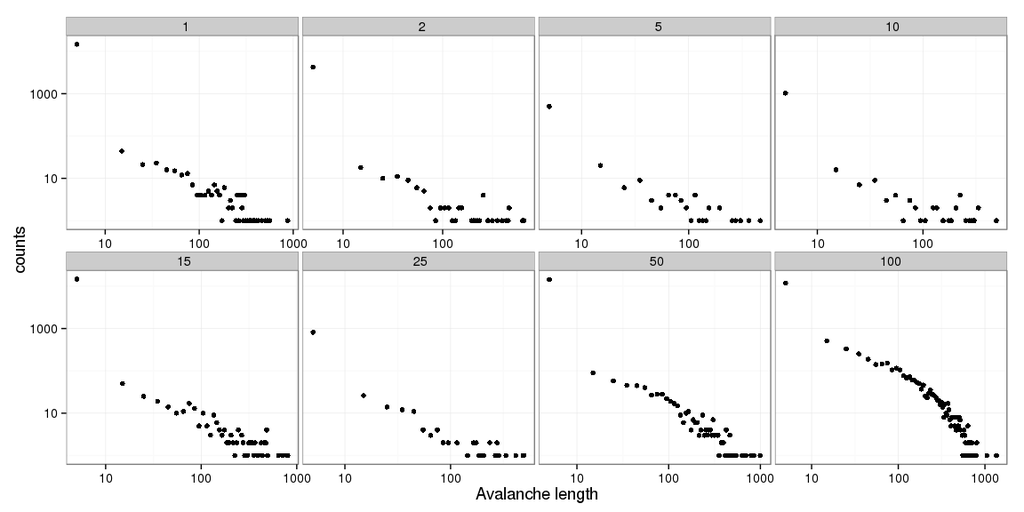

### Cumulative distribution function approach

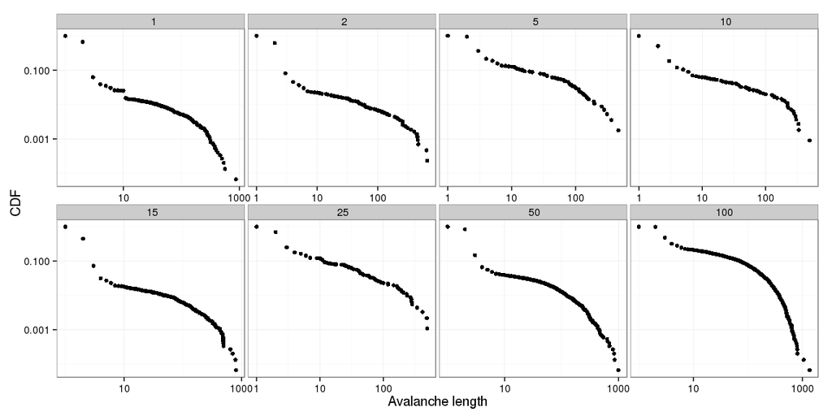

### Results of the fit

| perturb_n | xmin | alpha | KS | KS_p_value |
| --- | --- | --- | --- | --- |
| 1 | 252 | 4.288188 | 0.0555859 | 0.9999912 |
| 2 | 32 | 1.866177 | 0.0908447 | 0.6568163 |
| 5 | 76 | 2.692602 | 0.0905464 | 0.9833569 |
| 10 | 1 | 1.927059 | 0.0862687 | 0.0000002 |
| 15 | 104 | 2.348432 | 0.1004274 | 0.3177441 |
| 25 | 25 | 1.940498 | 0.0822152 | 0.7475366 |
| 50 | 259 | 3.613809 | 0.0631823 | 0.9767783 |
| 100 | 467 | 6.118841 | 0.0582973 | 0.9607449 |